# Asset Management GRA (Pierre Clauss): R Markdown project

Nadezhda Dobreva (20235059@etud.univ-evry.fr) and Youssef Louraoui (20230348@etud.univ-evry.fr)

2023-11-28

# 1. Global Minimum Volatility portfolio (GMV) on an Equity Portfolio

## 1.1 Packages

We import the necessary libraries to perform the first analysis.

1. **library(tidyverse):** The tidyverse package constitutes a collection of R packages meticulously designed to work seamlessly in unison for data manipulation, visualization, and analysis. It encompasses packages like ggplot2 for data visualization, dplyr for data manipulation, tidyr for data tidying, and more. Loading tidyverse avails all these packages for utilization during your R session, streamlining your data analysis workflow.
2. **library(quantmod):** The quantmod package primarily caters to quantitative financial modeling and analysis. It furnishes an array of functions and tools for handling financial data, such as downloading and managing stock price data, conducting technical analysis, and modeling financial time series.
3. **library(DataExplorer):** The DataExplorer package serves the purpose of preliminary data exploration and analysis. It offers functions to generate summary statistics, visualize missing data, plot variable distributions, and more. It can aid in obtaining a quick overview of your data before delving into more extensive analyses.
4. **library(corrplot):** The corrplot package specializes in visualizing correlation matrices. It provides functions for generating visually appealing and informative correlation plots, which prove valuable for comprehending relationships between variables within your data.
5. **library(scales):** The scales package provides an assortment of scales and formatting functions tailored for R graphics. It is often employed in conjunction with other plotting packages, such as ggplot2, to customize the appearance of plots, including axes, labels, and color scales.

## 1.2 Investment universe

### **1.2.1 Investment Universe**

In our portfolio management project, we have carefully chosen a set of twenty stocks from a larger universe of investments. This selection represents the most significant companies in the US equity market, primarily based on their market capitalization. By analyzing these stocks, our objective is to gain valuable insights into the strategies that can be employed for managing investments in the US equity market.

Our investment universe comprises a selection of twenty high-performing and influential companies, primarily from the technology sector. These companies are recognized for their robust market capitalization, innovative business models, and significant impact on global markets. They include:

- **AAPL (Apple Inc.)**: A leader in consumer electronics, software, and services.
- **MSFT (Microsoft Corporation)**: A global leader in software, services, devices, and solutions.
- **GOOGL (Alphabet Inc.)**: The parent company of Google, known for its dominant search engine and a wide array of internet services and products.
- **AMZN (Amazon.com, Inc.)**: A powerhouse in e-commerce, cloud computing, and artificial intelligence.
- **TSLA (Tesla, Inc.)**: An innovative company in electric vehicles, energy storage, and solar products.
- **NVDA (NVIDIA Corporation)**: A pioneer in graphics processing units (GPUs) for gaming and professional markets.
- **PYPL (PayPal Holdings, Inc.)**: A leading technology platform and digital payments company.
- **CMCSA (Comcast Corporation)**: A global media and technology company with two primary businesses, Comcast Cable and NBCUniversal.
- **ADBE (Adobe Inc.)**: A leader in multimedia and creativity software products.
- **ASML (ASML Holding N.V.)**: A leading supplier to the semiconductor industry.

These companies are selected not only for their individual performance but also for their collective ability to provide broad exposure to various subsectors within technology and adjacent industries. They encompass hardware, software, services, semiconductor, e-commerce, digital payments, media, and entertainment sectors.

- **CSCO (Cisco Systems, Inc.)**: A multinational technology conglomerate that develops, manufactures, and sells networking hardware, software, and other high-technology services and products.
- **PEP (PepsiCo, Inc.)**: A multinational food, snack, and beverage corporation.
- **AVGO (Broadcom Inc.)**: Designs, develops, and supplies a broad range of semiconductor and infrastructure software solutions.
- **TMUS (T-Mobile US, Inc.)**: A leading wireless network operator.
- **INTC (Intel Corporation)**: One of the world’s largest and highest valued semiconductor chip manufacturers.
- **TXN (Texas Instruments Incorporated)**: Designs and manufactures semiconductors and various integrated circuits.
- **AMGN (Amgen Inc.)**: Amgen is a leading biotechnology company that develops and manufactures drugs for a variety of diseases, including cancer, heart disease, and arthritis.
- **NFLX (Netflix, Inc.)**: A streaming service that offers a variety of TV series, documentaries, and feature films across a wide variety of genres and languages.
- **SBUX (Starbucks Corporation)**: A multinational chain of coffeehouses and roastery reserves.
- **AMAT (Applied Materials, Inc.)** is a leading provider of materials engineering solutions used to produce new chip and advanced display.

Overall, the investment universe selected includes a mix of large-cap US technology stocks (AAPL, MSFT, GOOGL, AMZN, TSLA, NVDA, PYPL, CMCSA, ADBE, ASML), consumer staples stocks (PEP), semiconductor stocks (AVGO, INTC, TXN), healthcare stocks (AMGN), and consumer discretionary stocks (NFLX, SBUX, AMAT).

### **1.2.2 Market outlook and link to portfolio allocation**

According to a recent survey of Wall Street analysts commented on Bloomberg, the median forecast for the S&P 500 index in 2023 is 4,300. Analysts are generally bullish on the US equity market in 2023, citing factors such as continued economic growth, strong corporate earnings, and low interest rates. However, they also acknowledge that there are some risks to the outlook, such as the potential for a recession and higher inflation. Here a market outlook for each stock selected in our investment universe:

- **AAPL (Apple)**: The company has a strong track record of innovation. The company is expected to benefit from the continued growth of the smartphone market and the launch of new products and services.
- **MSFT (Microsoft)**: The company has a diversified business model. They are expected to benefit from the growth of cloud computing and other enterprise software markets.
- **GOOGL (Alphabet)**: The company is also a leader in online advertising and cloud computing. Alphabet is expected to benefit from the continued growth of the digital economy.
- **AMZN (Amazon)**: The company is also a leader in cloud computing and other e-commerce businesses. Amazon is expected to benefit from the continued growth of online shopping and cloud computing.
- **TSLA (Tesla)**: The company is expected to benefit from the growing demand for electric vehicles and the transition to clean energy.
- **NVDA (Nvidia)**: GPUs are used in a variety of applications, including gaming, artificial intelligence, and data center computing. Nvidia is expected to benefit from the growth of these markets.
- **PYPL (PayPal)**: The company is expected to benefit from the growth of e-commerce and digital payments.
- **CMCSA (Comcast)**: The company is expected to benefit from the continued growth of broadband internet and the rollout of new streaming services.
- **ADBE (Adobe)**: The company’s products are used by a wide range of customers, including individuals, small businesses, and large corporations. Adobe is expected to benefit from the continued growth of the digital economy and the demand for creative software.
- **ASML (ASML Holding)**: Lithography systems are used to create the chips that are used in a wide range of electronic devices. ASML is expected to benefit from the growth of the semiconductor industry.
- **CSCO (Cisco Systems)**: The company’s products are used by businesses of all sizes to connect their networks and devices. Cisco is expected to benefit from the growth of digital transformation and the rollout of new technologies, such as 5G.
- **PEP (PepsiCo)**: The company has a strong portfolio of brands, including Pepsi, Doritos, and Frito-Lay. PepsiCo is expected to benefit from the continued growth of the consumer packaged goods industry.
- **AVGO (Broadcom)**: The company’s products are used in a range of electronic devices, including smartphones, computers, and networking equipment. Broadcom is expected to benefit from the growth of the semiconductor industry and the rollout of new technologies, such as 5G.
- **TMUS (T-Mobile US)**: The company is expected to benefit from the growth of the wireless data market and the rollout of 5G services.
- **INTC (Intel)**: The company is known for its microprocessors, which are used in a wide range of computers. Intel is also investing in new growth areas, such as data center computing and artificial intelligence. Intel is expected to benefit from the continued growth of the semiconductor industry.
- **TXN (Texas Instruments)**: The company’s products are used in a wide range of electronic devices, including smartphones, computers, and industrial equipment. Texas Instruments is expected to benefit from the continued growth of the semiconductor industry.
- **AMGN (Amgen)**: The company develops and manufactures a wide range of drugs, including treatments for cancer, heart disease, and other chronic diseases. Amgen is expected to benefit from the growth of the biotechnology industry and the aging population. The global population is aging, and this is creating demand for new drugs to treat the diseases that are associated with aging. Amgen’s products are well-positioned to benefit from this trend. The biotechnology industry is one of the fastest-growing industries in the world. Amgen is a leading player in this industry, and it is well-positioned to benefit from its continued growth. Also, Amgen is heavily invested in research and development, and this is expected to help the company develop new and innovative drugs in the future.
- **NFLX (Netflix)**: The company offers a wide range of TV shows and movies to subscribers on demand. Netflix is expected to benefit from the continued growth of the streaming entertainment industry. The streaming entertainment market is expected to continue to grow in the coming years, as more and more consumers shift away from traditional cable and satellite TV. On the same line, Netflix is investing heavily in original content production, and this is expected to help the company attract and retain subscribers.
- **SBUX (Starbucks)**: The company has a strong brand and a loyal customer base. Starbucks is expected to benefit from the economic rebound of the US economy. Starbucks is expected to benefit from a number of trends. The global coffee market is expected to continue to grow in the coming years, driven by rising incomes and increasing urbanization in emerging markets. Also, China is one of Starbucks’ largest and fastest-growing markets. The company is investing heavily in expanding its store network and developing new products for the Chinese market.
- **AMAT (Applied Materials, Inc.):** The company’s products are used by semiconductor manufacturers around the world to produce the most advanced chips and displays. Applied Materials is expected to benefit from a number of trends, including growth in the semiconductor industry which is expected to continue to grow in the coming years, driven by demand for new chips from a variety of industries, including consumer electronics, automotive, and data center.Also, the display market is also expected to grow in the coming years, driven by demand for new and larger displays for smartphones, TVs, and other electronic devices. Applied Materials is a leading provider of materials engineering solutions for the display industry.

### **1.2.3 Rationale for this investment universe selection**

The rationale behind this selection lies in diversification across various dimensions, including market capitalization, geographical presence, and revenue streams, while maintaining a focus on growth and innovation. The intent is to capture both the stability of established companies and the growth potential of market leaders and innovators. In this sense, the choice of stocks is guided by several key considerations:

- **Investment universe:** Our selection is drawn from a universe of stocks that encompasses twenty well-established companies within the US equity market. These companies are known for their substantial market presence and are recognized leaders in their respective industries.
- **Market capitalization focus:** We have chosen stocks with an emphasis on market capitalization. Larger market capitalization often indicates stability and lower volatility, making these stocks appealing for various investment strategies.
- **US equity market perspective:** Our project primarily targets insights related to the US equity market. The chosen stocks provide a representative snapshot of the investment landscape in one of the world’s largest and most influential equity markets.
- **Diversification:** To create a well-rounded portfolio, we have ensured diversification across different sectors and industries. Diversification is essential in portfolio management as it spreads risk and mitigates overexposure to a single sector.
- **Market visibility:** The selected companies are not only well-regarded in the financial sector but are also widely recognized in popular culture. Their performance is closely monitored, and they often hold significant sway over market indices.
- **Historical data and research:** These stocks have a rich history of performance data and have been the subject of extensive research. Access to their historical data is abundant, making them suitable for rigorous portfolio management analysis and research.

The provided R code defines the stock tickers for these companies, allowing you to access financial data. This data can then be employed to conduct a range of analyses, such as return calculations, risk assessments, and portfolio optimization, to test and implement various investment strategies on the US equity market.

## 1.3 Data cleaning and analysis

### 1.3.1 Data cleaning

We perform some formatting to clean the data, an important step in performing data analysis:

- **Extracting adjusted closing prices** (lapply(stock_tickers, function(ticker) { Ad(get(ticker)) })): This code uses the lapply function to retrieve the adjusted closing prices (often used for return calculations) for a list of stock tickers. It iterates through each ticker in the stock_tickers vector and fetches the adjusted closing prices using the Ad() function from the quantmod package.
- **Combining stock returns** (do.call(cbind, stock_returns)): The code combines the extracted adjusted closing prices into a single data frame by calling cbind (column-bind) on the list of stock returns obtained in the previous step. This creates a data frame where each column represents the adjusted closing prices of a specific stock.
- **Renaming columns** (colnames(fin_prices) <- stock_tickers): The code assigns the stock tickers as column names to the combined data frame. This step ensures that each column is labeled with the corresponding stock ticker, making it easier to identify each stock’s data.
- **Handling missing data** (na.omit(fin_prices)): This line of code removes rows with missing values (usually represented as NA) from the combined data frame, fin_prices. Removing missing data is a common processing step to ensure the quality and consistency of the dataset for further analysis.

We perform the arithmetic return method to compute returns for this data set. It is simple, intuitive and widely accessible. Arithmetic returns are particularly useful for performance measurement, providing a clear view of actual gains and losses. It is well-suited for short-term analysis and offer transparency.

### 1.3.2 Data analysis

The US stock market has performed strongly from 2019 to 2023, despite some headwinds. The S&P 500 index has returned double digit returns during this period, driven by a number of factors, including:

- **Strong economic growth:** The US economy grew at an average rate of 2.3% from 2019 to 2022, which supported corporate earnings growth.
- **Low interest rates:** The Federal Reserve kept interest rates at record lows during this period, which boosted corporate profits and made stocks more attractive to investors.
- **Government stimulus:** The US government injected a number of stimulus measures in response to the COVID-19 pandemic, which boosted consumer spending and supported the economy.

The main market movers during this period have been technology stocks, which have outperformed other sectors by a wide margin. This is due to the fact that technology companies have benefited from the shift to online shopping and working during the pandemic.

Other sectors that have performed well during this period include healthcare, consumer staples, and financials. These sectors are generally seen as more defensive, and they have tended to outperform in times of market volatility.

Some of the top performing US stocks from 2019 to 2023 include:

- **NVIDIA (TICKER: NVDA)**
- **Tesla (TICKER: TSLA)**
- **Apple (TICKER: AAPL)**
- **Microsoft (TICKER: MSFT)**
- **Alphabet (TICKER: GOOGL)**
- **Amazon (TICKER: AMZN)**

These companies have all benefited from the trends mentioned above, and they have seen their share prices rise significantly during this period. Overall, the US stock market has performed strongly from 2019 to 2023, despite some headwinds. The main market movers have been technology stocks, which have outperformed other sectors by a wide margin.

From the figure below, Nvidia (TICKER: NVDA) and Tesla (TICKER: TSLA) stock shares witnessed an unprecedented surge in attraction, making it a notable standout within our investment universe. Tesla was among the best performing stocks in the broader investment universe selected. The surge in retail trading interest for the electric car company can explain to some extent this massive performance, especially in the wake of the post-COVID market, where intensive monetary policies prompted significant investments from both corporate and retail investors seeking higher yields.

Regarding Nvidia’s stock price, it has surged in recent years as investors have become increasingly bullish on the company’s prospects. There are a number of reasons for this, including:

- **The growth of AI:** AI is one of the most important technological trends of our time, and Nvidia’s GPUs are essential for many AI applications. As AI continues to grow, Nvidia is well-positioned to benefit.
- **The rise of the metaverse:** The metaverse is a virtual world that is still in its early stages of development, but it has the potential to be a massive market. Nvidia’s GPUs are used to power many of the technologies that will be used in the metaverse, such as virtual reality and augmented reality.
- **Nvidia’s strong financial performance:** Nvidia has been delivering strong financial performance for many years. In the most recent quarter, the company reported revenue of $8.29 billion and earnings per share of $1.32, both of which beat analyst expectations.

Given Nvidia’s strong position in the AI and metaverse markets, it is not surprising that investors are paying attention to the stock. The company is also well-managed and has a strong track record of innovation.

Here are some specific reasons why investors are interested in NVDA stock amid a rising war in AI and LLM:

- **Nvidia is a leader in the development of AI hardware and software.** The company’s GPUs are used by many of the world’s leading AI researchers and companies.
- **Nvidia is well-positioned to benefit from the growth of LLM.** LLMs are a new type of AI that can generate text, translate languages, write different kinds of creative content, and answer your questions in an informative way. Nvidia’s GPUs are essential for training and running LLMs.
- **Nvidia is investing heavily in the research and development of new AI technologies.** The company is committed to maintaining its leadership position in the AI market.

Overall, Nvidia is a well-established company with a strong track record of innovation. The company is well-positioned to benefit from the growth of AI and LLM, which is why investors are paying attention to the stock.

The code allowed us to plot returns into a time series, providing a clear visualization of stock performance during the specified period.

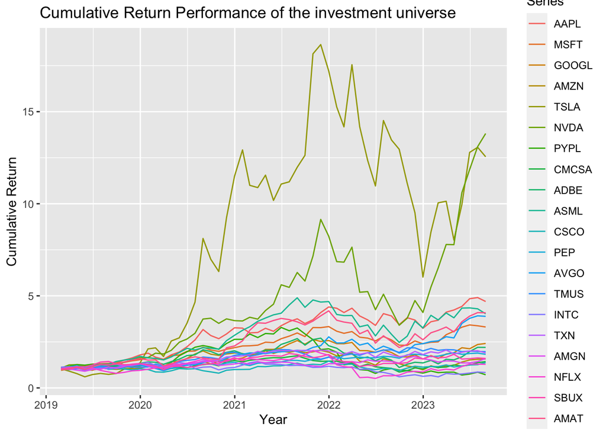

Cumulative return of stocks across the analysed period.

We can define the Minimum Volatility Portfolio (MVP) as a portfolio of assets with the lowest possible risk for an investor and is located on the far-left side of the efficient frontier. Note that the minimum volatility portfolio is also called the minimum variance portfolio or more precisely the global minimum volatility portfolio (to distinguish it from other optimal portfolios obtained for higher risk levels).

To implement to global minimum variance portfolio, we need to compute the covariance matrix as an input parameter for the Markowitz optimization model.

**Interpreting the Correlation Matrix**

We can highlight the following observations on the correlation matrix:

- **Predominant positive correlations:** The majority of the correlations in the matrix are positive, indicating that most of the stocks tend to move in the same direction. This is a common characteristic of stocks within the same market, as they are often influenced by similar economic factors and market sentiment. The plot shows that there is a significant amount of correlation between many of the stocks in the portfolio. This is not surprising, as many stocks in the same sector or industry tend to move in the same direction. For example, the correlation between the tech stocks in the portfolio (AAPL, MSFT, GOOGL, TSLA, NVDA, and AMZN) is very high. The high correlation between the stocks in the portfolio means that the portfolio is not as diversified as it could be. A more diversified portfolio would have a lower overall correlation, as the stocks would be more likely to move in different directions.
- **Varying correlation strengths:** The shades of the correlation coefficients vary, indicating that the strength of the correlations between stocks differs. Some stocks exhibit strong positive correlations, while others have weaker correlations. This suggests that the portfolio has a mix of stocks with varying degrees of co-movement.

**Linking Findings with Markowitz Portfolio Theory**

Markowitz portfolio theory, also known as Modern Portfolio Theory (MPT), emphasizes the importance of diversification in reducing portfolio risk. The theory suggests that by combining assets with varying correlations, investors can achieve a portfolio with a lower overall risk for a given level of expected return.

**Implications for Portfolio Construction**

The correlation matrix provides valuable insights for portfolio construction. By understanding the correlations between stocks, investors can make informed decisions about asset allocation and diversification strategies.

- **Diversification:** The concept of diversification seeks to enhance returns while minimizing risk by investing in a variety of assets that will react differently to the same event (s). For example, whenever there is unfavorable news about a certain event, i.e. 2008 sub prime mortgage crisis, the stock market typically declines dramatically. Simultaneously, the same news has generally benefited the price of specific assets, such as gold. As a result, portfolio diversification should include not just diverse stocks inside and outside of the same industry, but also diverse asset classes, such as bonds and commodities. The diversification effect is a term that relates to the link between portfolio correlations and diversification. When there is an imperfect correlation between assets (positive or negative), the diversification effect occurs. It is a critical and successful risk mitigation method since risk mitigation may be accomplished without sacrificing profits. As a result, any prudent investor who is ‘risk cautious’ will diversify to a certain extent.
- **Risk Management:** The correlation matrix can be used to assess the overall risk profile of the portfolio. A portfolio with predominantly strong positive correlations may be more susceptible to market downturns, while a portfolio with a mix of positive, negative, and weak correlations may exhibit more stability.
- **Rebalancing:** The correlation matrix can guide rebalancing decisions. If certain stocks or sectors become overly correlated, investors may consider rebalancing their portfolio to maintain an appropriate level of diversification.

In conclusion, the correlation matrix is a valuable tool for understanding the relationships between assets in a portfolio. By analyzing the correlation patterns, investors can make informed decisions about diversification, risk management, and rebalancing strategies, aligning with the principles of Markowitz portfolio theory. We observe opportunities for diversification within our investment universe. For instance, we notice that stocks often categorized as defensive plays can serve as effective diversification instruments when combined with more aggressive stocks. In this context, consider Amgen Inc. (TICKER: AMGN) in the healthcare industry, which exhibits a neutral correlation when compared to a stock like Tesla (TICKER: TSLA). Similar logic applies to a stock such as PepsiCo Inc. (TICKER: PEP) in relation to Tesla. It’s worth noting that within our investment universe, we do not find negative correlations, as all the assets exhibit some degree of correlation to one another.

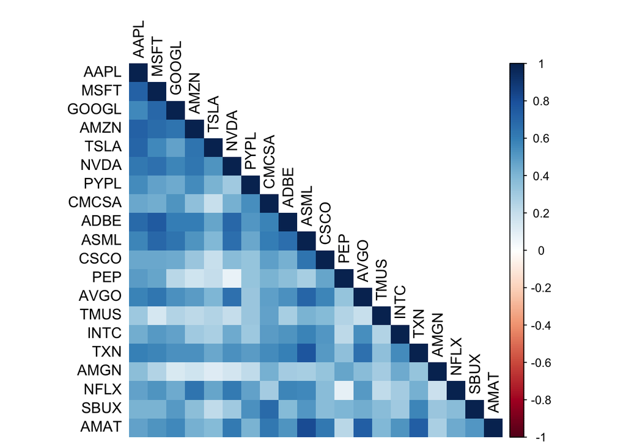

Correlation return of stocks across the analysed period.

Using monthly data to smooth the data and transform it to a close approximation to the Gaussian distribution has several advantages:

- **Reduced noise:** Monthly data is less noisy than daily or weekly data. This is because it averages out the short-term fluctuations in the data.
- **Improved normality:** Monthly data is more likely to be normally distributed than daily or weekly data. This is because the Central Limit Theorem states that the distribution of the sum of a large number of independent and identically distributed random variables will be approximately normal, even if the original distribution is not normal.
- **Easier to model:** Gaussian distributions are easier to model than other types of distributions. This is because there are a number of well-established statistical methods for modeling Gaussian distributions.

There are also some disadvantages to using monthly data to smooth the data and transform it to a close approximation to the Gaussian distribution:

- **Loss of information:** Monthly data is less informative than daily or weekly data. This is because it averages out some of the detail in the data.
- **Time lag:** Monthly data has a time lag. This means that it does not reflect the latest changes in the underlying data.

Overall, the utility of using monthly data to smooth the data and transform it to a close approximation to the Gaussian distribution depends on the specific application. In order to reduce noise and improve normality, then using monthly data is a good option. However, if the goal is to capture the latest changes in the data or to preserve all of the information in the data, then using more frequent data is a better option.

The data taken in this analysis spans from early January 2019 to August 2023. This is a relatively long period of time, so using monthly data should be sufficient to reduce noise and improve normality. However, the data may be subject to have a time lag.

For portfolio optimization under a Markowitz framework, using monthly data is a good choice to deal with the normality assumption of the Markowitz model. In addition to that, supplementary statistical analysis can help understand financial patterns in data:

- First, density plots, also known as probability density function plots, serve the purpose of visualizing data distributions. They offer insights into the shape, spread, and central tendencies of data, making them crucial for assessing the nature of financial asset returns.
- Second, QQ plots, or quantile-quantile plots, are utilized to evaluate whether a dataset adheres to a specific theoretical distribution, such as the normal distribution. These plots help portfolio managers identify departures from expected distributions, facilitating informed investment decisions. Together, these techniques aid in the exploration and assessment of financial data, enabling portfolio managers to make more informed and data-driven choices in their investment strategies.

## 1.4 Modelling part

Modern Portfolio Theory (MPT) is founded on several market and investor assumptions. Several of these assumptions are stated explicitly, while others are implied. Markowitz’s contributions to (MPT) in portfolio selection are based on the following basic assumptions:

- Investors are rational (they seek to maximize returns while minimizing risk, or minimize risk while maximize return).
- Investors will accept increased risk only if compensated with higher expected returns.
- Investors receive all relevant information regarding their investment decision.
- Investors can borrow or lend an unlimited amount of capital at a risk-free rate of interest.

### 1.4.1 Unbiased Global Minimum Variance (GMV) portfolio

The GMV portfolio is only based on the covariance matrix estimation. This matrix estimator is inversed in the formula to determine the weights of the portfolio. The unbiased estimator of the inverse covariance matrix can be approached as :

$$\hat{\Sigma}{\text{unbiased}} = \frac{1}{T - n - 2} \sum{t=1}^{T} (r_t -
\hat{\mu})(r_t - \hat{\mu})'$$

where $\hat{\mu} = \frac{1}{T} \sum_{t=1}^{T} r_t$ is an estimator for the mean returns, T the number of observations, n the number of assets and rt the vector of financial returns for the n assets observed at time t.

In the context of time series data analysis, one of the crucial applications is the division of the data set into a training set and a testing set based on temporal order. This approach is particularly important when dealing with data that evolves over time, such as stock prices in this instance.

The training set typically comprises historical data, while the testing set contains more recent observations. This temporal separation allows for the evaluation of predictive models and forecasting techniques. By using historical data to train the model and then assessing its performance on more recent data, analysts can gauge the model’s ability to make accurate predictions and anticipate future trends. Time series data applications are essential in fields like finance, where understanding and forecasting trends over time is important.

For the purpose of modelling, we will shrink the data set into two different sub-samples. We can define the following parameters:

1. The first sub-sample will cover the first 20 trading month covered in the data set.

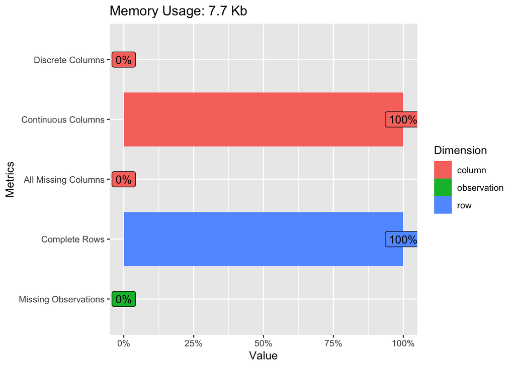

Structure of the first subsample.

2. The second sub-sample will cover the rest of the data set, covering the equivalent of 36 trading month.

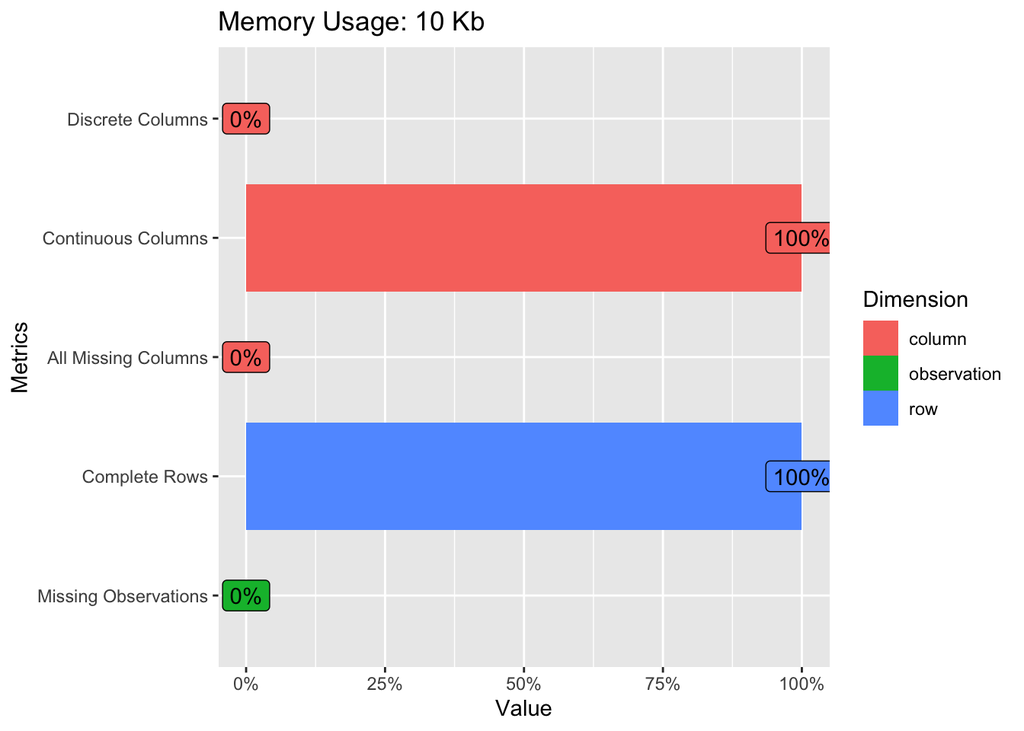

Structure of the second subsample.

We implement the parameters of the model in order to compute the GMV:

After computing the parameters required to implement the unbiased GMV portfolio, we can compute omega, representing the weightings of the portfolio as follows.

We can see in this instance that the portfolio is mixed, with some long and short positions. The capital is fully invested, with some important exposure in the long part of the portfolio on stocks like Adobe (TICKER: ADBE) with 94.61%, followed by PepsiCo (TICKER: PEP) at 73.15%. and T-Mobile (TICKER: TMUS) at 55.69%.

On the short part of the portfolio, we can see an important short on three stocks that can stand out: Microsoft (TICKER: MSFT) -49.83%, ASML corporation (TICKER: ASML) at -43.22% and Paypal (TICKER: PYPL) at -40.79%.

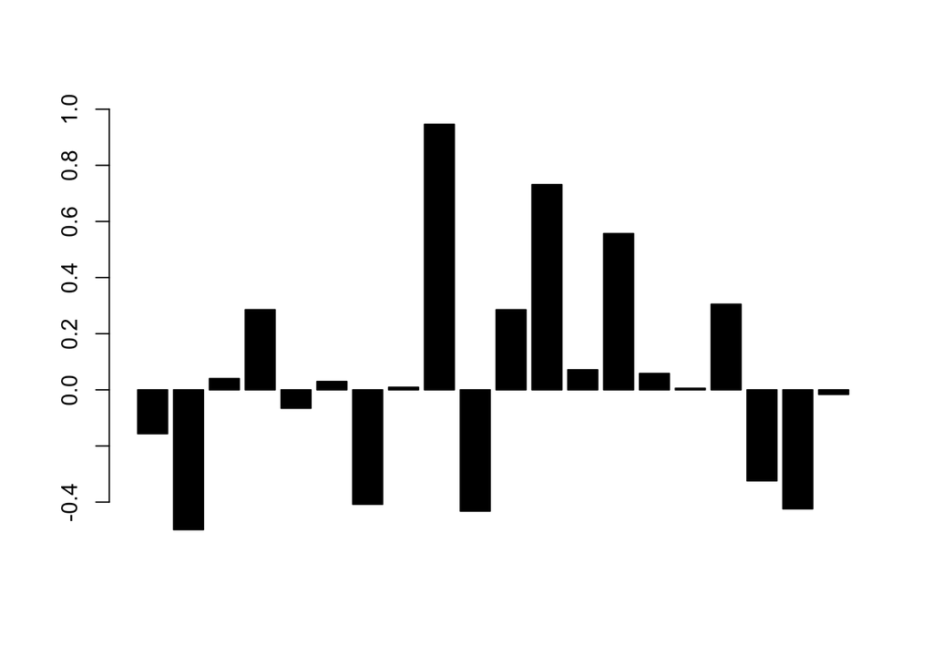

GMV portfolio weights. Each represent a stock weight (from left to right: AAPL, MSFT, GOOGL, AMZN, TSLA, NVDA, PYPL, CMCSA, ADBE, ASML, CSCO, PEP, AVGO, TMUS, INTC, TXN, AMGN, NFLX, SBUX, AMAT.

### 1.4.2 Implementation of Principal Component Analysis (PCA)

Principal Component Analysis (PCA) is a technique used to analyze and reduce the dimensionality of a dataset while retaining as much variance as possible. We perform the PCA analysis using the second subsample starting from the trading month number 20 of the sample to the trading month number 56.

Principal component analysis (PCA) is an unsupervised machine learning technique that can be used to identify the underlying patterns in a dataset. PCA works by transforming the dataset into a new set of variables, called principal components, that are uncorrelated with each other. The principal components are ordered in terms of how much variance they explain in the dataset, with the first principal component explaining the most variance and the last principal component explaining the least variance.

PCA can be used for a variety of tasks, including dimensionality reduction, data visualization, and feature extraction. In the context of portfolio management, PCA can be used to:

- Identify the underlying factors that drive the returns of the stocks in the portfolio.
- Construct more diversified portfolios by selecting stocks with low correlations with each other.
- Reduce the dimensionality of the portfolio by selecting the most important principal components.

For a three factor model, we can approach it mathematically:

$$\hat{\Sigma}_{3\text{factors}} = \Phi_f \Lambda_f \Phi' +
\Sigma\epsilon$$

The variance of the residuals $\epsilon_i$ can be computed as (Clauss, 2011):

$$\begin{equation}
\text{Var}(\epsilon_i) = \text{Var}(r_i) - \phi_{i1}^2 \lambda_1 -
\phi_{i2}^2 \lambda_2 - \phi_{i3}^2 \lambda_3
\end{equation}$$

with $\Lambda_f$ representing the diagonal matrix of the first three eigenvalues of the unbiased estimator of the covariance matrix, $\Phi_f$ the matrix with the first three eigenvectors, and $\Sigma_{\epsilon}$ the diagonal residual covariance matrix determined for each asset $i$.

The PCA results can be interpreted as follows:

- The first principal component can be thought of as a market factor. This factor represents the overall movement of the stock market. In other terms, the first factor explains half of the variance of the portfolio overall and can be assimilated as a proxy to the sensitivity to market fluctuations.
- The second and third principal components can be thought of as style factors. These factors represent the different styles of investing, such as value investing and growth investing. From the type of stocks retained, we have shortlisted an important number of growth stocks in the technology sector, which could explain part of the overall variance of the portfolio.
- The remaining principal components can be thought of as idiosyncratic factors. These factors are specific to the individual stocks in the portfolio.

The below plot represents the portfolio allocation using the PCA method.

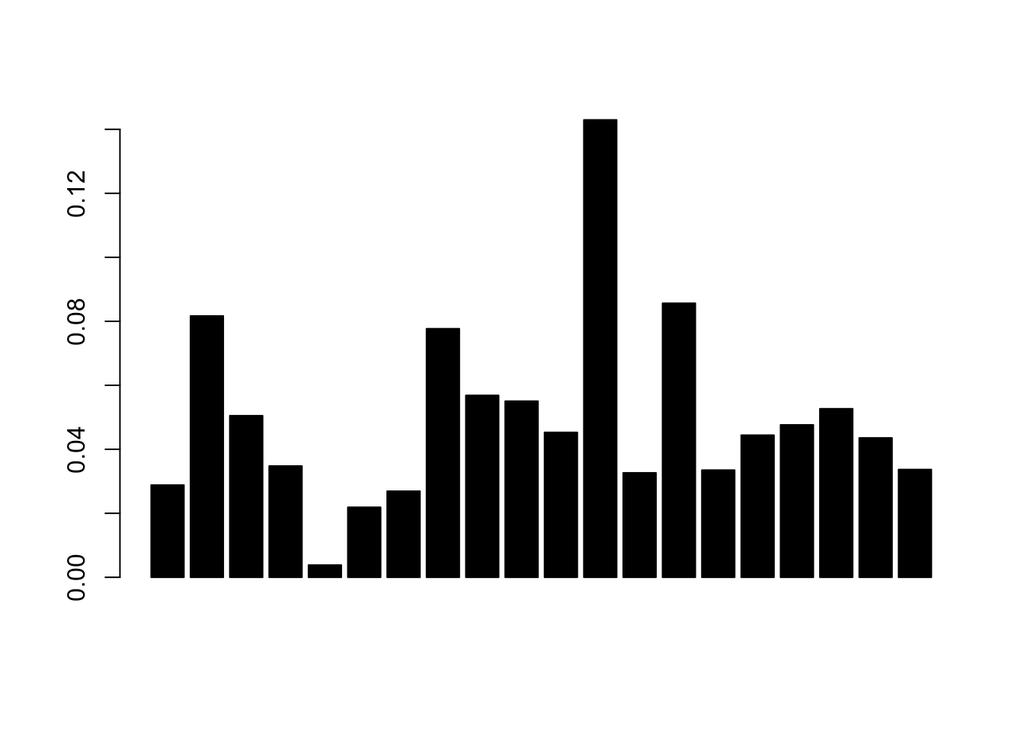

PCA portfolio weights. Each bar represent a stock weight (from left to right: AAPL, MSFT, GOOGL, AMZN, TSLA, NVDA, PYPL, CMCSA, ADBE, ASML, CSCO, PEP, AVGO, TMUS, INTC, TXN, AMGN, NFLX, SBUX, AMAT.

# 2. Tangency Portfolio and Black-Litterman Approach

## 2.1 Packages

We use the same packages as described on 1.1.

## 2.2 Investment universe

### **2.2.1 Investment universe**

This investment universe is designed to provide diversified exposure across a range of asset classes, including broad market indices, emerging market equities, government bonds, commodities, and precious metals. This selection is intended to balance risk and return while capturing growth opportunities and providing a hedge against inflation.

- VTI (Vanguard Total Stock Market ETF): Broad exposure to the global stock market.
- EMGF (iShares MSCI Emerging Markets Multifactor ETF): Exposure to emerging markets with favorable exposure to value, quality, momentum, and size factors.
- IEF (iShares 7-10 Year Treasury Bond ETF): Exposure to intermediate-term government bonds.
- DBC (Invesco DB Commodity Index Tracking Fund): Exposure to a basket of commodities.
- GLD (SPDR Gold Trust): Exposure to gold.

### **2.2.2 Economic data**

To connect our investment universe selection to the asset allocation, we can refer to market outlooks from the prominent Wall Street most reliable market commentaries. We take the economic data from Goldman Sachs Asset Management, BlackRock, and JPMorgan Asset Management:

| Firm | Global GDP Growth | US GDP Growth | Eurozone GDP Growth | China GDP Growth | S&P 500 Earnings | US 10-year Treasury Yield |
| --- | --- | --- | --- | --- | --- | --- |
| BlackRock | +3.1% | +2.3% | +2.1% | +5.3% | +10% | 3.3% |
| GSAM | +2.8% | +1.8% | +0.6% | +5.0% | +6% | 3.5% |
| JPMAM | +3.2% | +2.0% | +2.0% | +5.2% | +8% | 3.0% |

Source: Data from BlackRock, Goldman Sachs Asset Management (GSAM), and J.P. Morgan Asset Management (JPMAM), 2023.

On average, the three financial institutions expect global GDP growth of +3.0% in 2023, US GDP growth of +2.0%, and S&P 500 earnings growth of +8%. They also expect the US 10-year Treasury yield to reach 3.3%.

In terms of asset allocation, all three institutions are overweight on equities, with Goldman Sachs Asset Management being the most overweight. They are also underweight on bonds, with JPMorgan Asset Management being the most underweight.

Overall, the market outlooks from these three financial institutions suggest that equities are still the preferred asset class for 2023, despite the expected slowdown in economic growth. Investors should consider diversifying their portfolios with other asset classes, such as bonds and commodities, to reduce risk.

This investment universe is a good option for investors who are looking for a diversified portfolio that offers the potential for both growth and income. The assets in this universe are supported by economic data, market outlook, and investment considerations.

### 2.2.3 Rationale

We have carefully chosen a set of five trackers (ETFs) to represent our investment universe. An ETF can be defined as a financial product that is based on a basket of different assets, to replicate the actual performance of each selected investment. An ETF has more or less the same proportion of the underlying components of the basket, depending on the style of management of the asset manager. Below is the Exchange-Traded Funds (ETF) chosen as the investment universe.

- **Equities (VTI):** VTI provides broad exposure to the global stock market, which is expected to benefit from economic growth.
- **Emerging market equities (EMGF):** EMGF provides exposure to emerging markets with favorable exposure to value, quality, momentum, and size factors. Emerging markets have the potential for higher growth than developed markets, but they also come with more risk. EMGF mitigates some of the risk by investing in companies with favorable exposure to specific factors.
- **Government bonds (IEF):** IEF provides exposure to intermediate-term government bonds, which are typically considered to be low-risk investments. This can provide stability to a portfolio in times of economic uncertainty.
- **Commodities (DBC):** DBC provides exposure to a basket of commodities, which can be a good way to diversify a portfolio and hedge against inflation. However, it is important to note that commodities are volatile investments.
- **Precious metals (GLD):** GLD provides exposure to gold, which is a traditional safe haven asset that can provide protection against inflation and market volatility.

Overall, this investment universe is well-diversified and offers a mix of assets with different risk and return profiles. This makes it a good choice for investors with a variety of investment objectives and time horizons.

Our selection strategy is based on several fundamental considerations:

- **Investment universe:** The investment universe aims at representing different asset classes in order to construct a multi-asset portfolio.
- **Diversification strategy:** Our commitment to constructing a well-rounded portfolio has been affirmed through diversification across various sectors and industries. Such diversification is a critical risk management tool, curbing overexposure to a single sector or asset class.
- **Historical data availability:** The selected trackers benefit from a rich repository of historical data and extensive research. The accessibility of such data enable these ETFs to rigorous portfolio management analysis and comprehensive research.

The provided R code defines the tickers for these trackers, allowing you to access the financial data. This data can then be employed to conduct a range of analyses, such as return calculations, risk assessments, and portfolio optimization, to test and implement various investment strategies.

## 2.3 Data cleaning and analysis

### 2.3.1 Data cleaning

We initiate data cleaning, a crucial step in data analysis:

- **Extracting adjusted closing prices:** We use the lapply function to obtain adjusted closing prices, commonly used for return calculations, for a list of stock tickers. This code iterates through each ticker and fetches the adjusted closing prices.
- **Combining stock returns:** To consolidate the adjusted closing prices, we employ cbind, creating a data frame where each column represents a specific stock’s adjusted closing prices.
- **Renaming columns:** We label the columns with their corresponding stock tickers, facilitating easy identification.
- **Handling missing data:** We remove rows with missing values from the dataset for quality and consistency.

Arithmetic returns are used for performance assessment, offering a clear view of gains and losses, suitable for short-term analysis, and ensuring transparency.

In order to ensure that the data is properly imported, with non missing values and proper data cleaning procedure, we can implement this line of code in order to learn more about data.

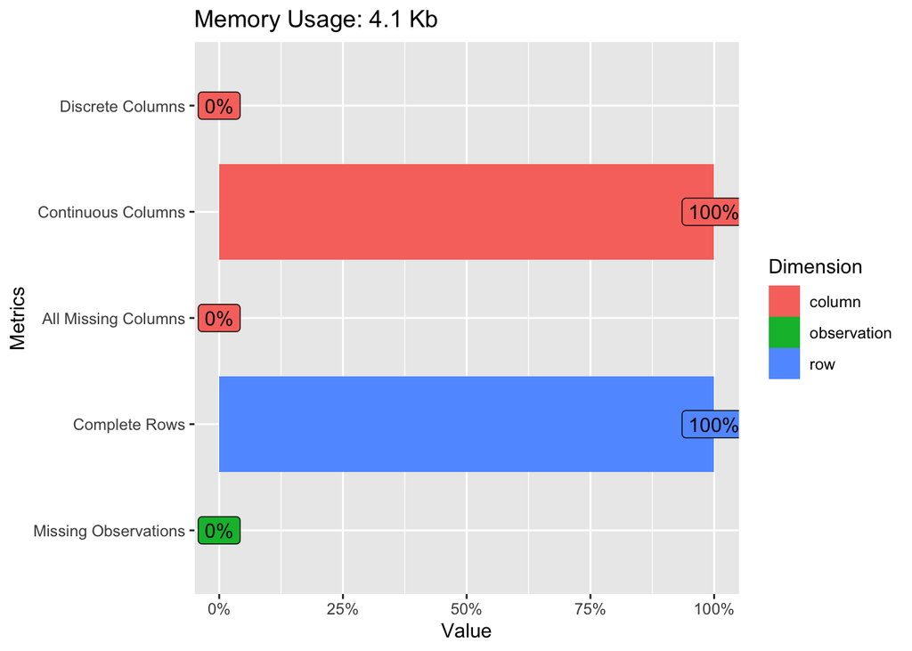

Data structure of the price imported from Yahoo Finance.

### **2.3.2 Data analysis**

The equity market has outperformed all of the other asset classes mentioned above since 2019 for a number of reasons.

- **Strong economic growth:** The global economy has grown at a healthy pace since 2019, which has supported corporate earnings growth. This has made equities more attractive to investors.
- **Low interest rates:** Interest rates have been low since 2019, which has made equities more attractive relative to other asset classes, such as bonds.
- **Government stimulus:** Governments around the world have enacted a number of stimulus measures to support the economy during the COVID-19 pandemic. This has boosted consumer spending and investment, which has benefited equities.
- **Corporate earnings growth:** Corporate earnings have grown strongly since 2019, as companies have benefited from the strong economy and low interest rates. This has made equities more attractive to investors.

The equity market is the riskiest of the asset classes mentioned above because it is more volatile and subject to larger swings in price. However, it has also been the most rewarding asset class over the long term, as it has generated higher returns than other asset classes, such as bonds and commodities.

Here are some additional insights on the outperformance of the equity market:

- The equity market has benefited from a number of technological trends, such as the rise of e-commerce and cloud computing. These trends have led to the growth of new companies and industries, which has created new investment opportunities for investors.
- The equity market has also benefited from the globalization of the economy. Companies are now able to operate in multiple countries, which has helped them to grow their businesses and increase their profits.
- The equity market has become more accessible to individual investors in recent years. This has led to an increase in demand for equities, which has helped to drive up prices.

Overall, the equity market has outperformed all of the other asset classes mentioned above since 2019 due to a number of factors, including strong economic growth, low interest rates, government stimulus, corporate earnings growth, technological trends, globalization, and increased access for individual investors.

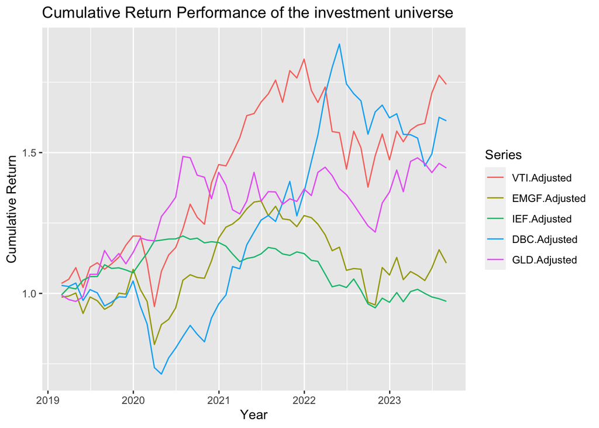

Cumulative return of the funds over the selected period.

Correlation is a fundamental concept related to diversification, which seeks to use poorly correlated and non correlated assets to construct a portfolio. Diversification aims to boost returns while minimizing risk by investing in assets that respond differently to various events. Prudent investors seeking risk mitigation will diversify their portfolios.

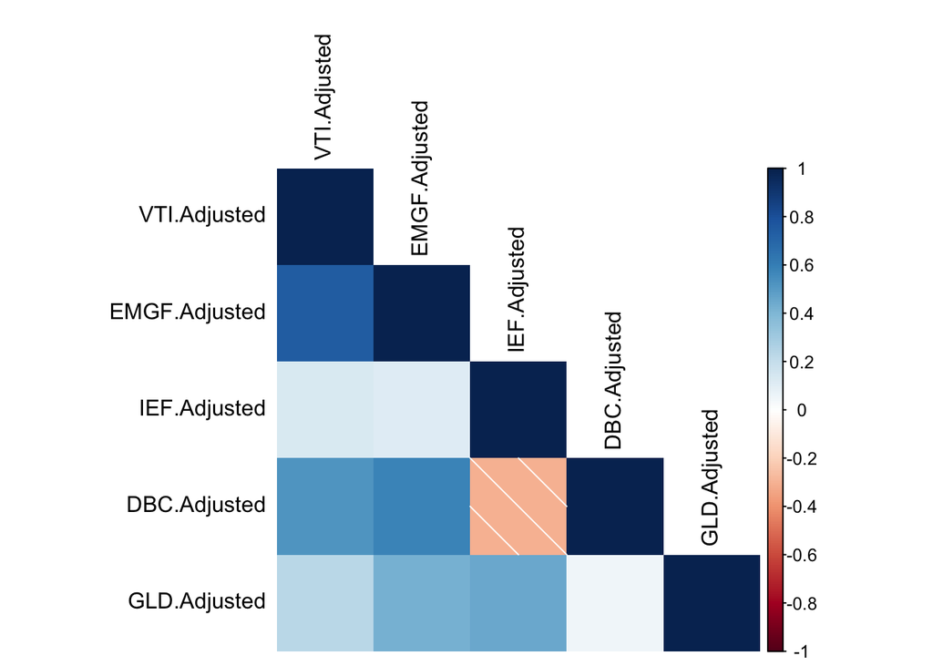

Correlation of returns of the funds over the selected period.

## 2.4 Modelling of the portfolio

### 2.4.1 Implementing the Tangency portfolio (TP)

In time series data analysis, a crucial application involves splitting the dataset into training and testing sets based on temporal order. This is vital when working with data that evolves over time, such as stock prices or weather observations.

The training set consists of historical data, while the testing set contains more recent observations. This division allows analysts to assess predictive models and forecasting techniques. By training the model on historical data and evaluating it with recent data, we can determine its ability to make accurate predictions. This is especially important in finance for understanding and forecasting trends over time.

For modeling purposes, we’ll create two sub-samples with defined parameters.

1. The first sub-sample will cover the first 20 trading month covered in the data set.

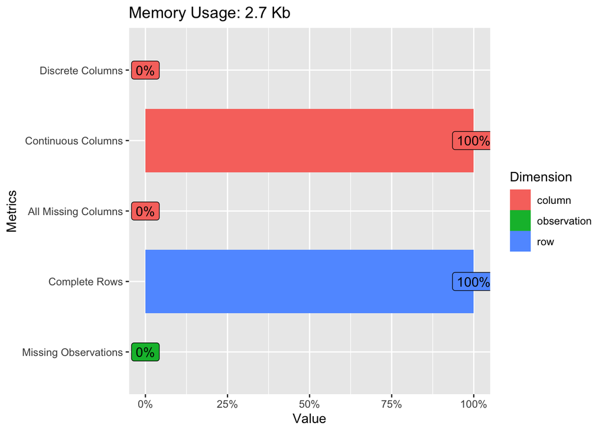

Structure of the first subsample.

2. The second sub-sample will cover the rest of the data set, covering the equivalent of 36 trading months.

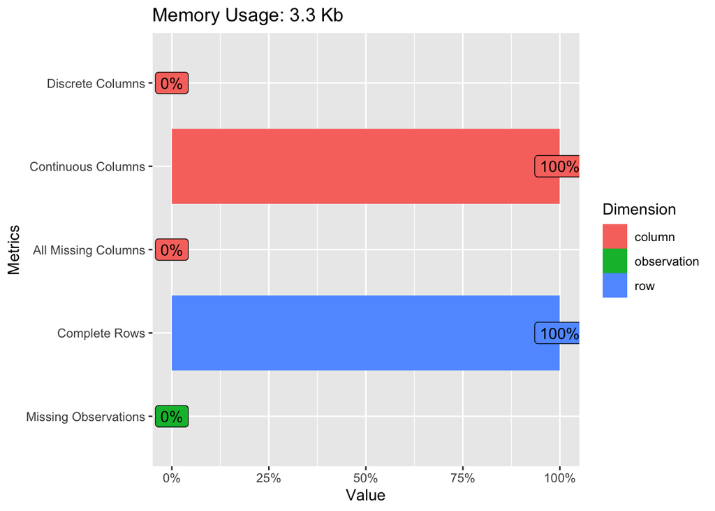

The portfolio allocation consists of both long positions, where investors expect favorable returns, and short positions, where they anticipate weaker performance. Here’s a more detailed explanation of each asset class allocation:

Long Positions: The long segment of the portfolio is allocated to assets where positive performance is expected.

Short Positions: The short segment of the portfolio is allocated to assets where weak performance is expected.

In summary, the portfolio is strategically balanced between long positions, where investors have confidence in the assets’ growth potential, and short positions, where they are expecting weaker performance. The specific allocations provide insights into the level of conviction and sentiment regarding each asset class.

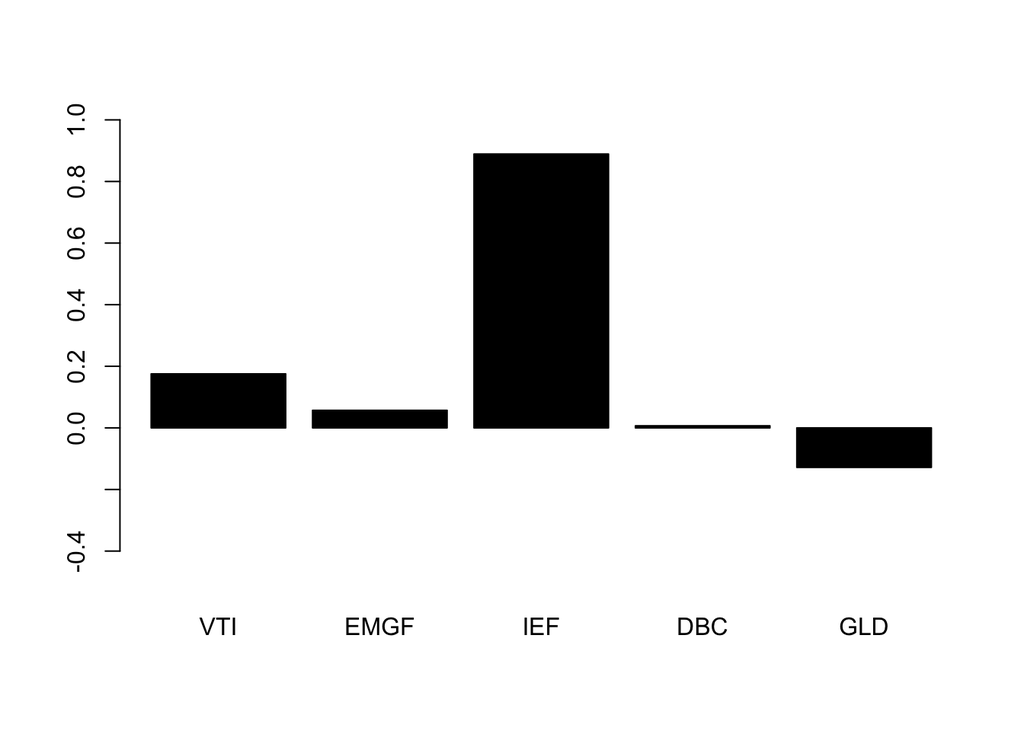

Tangency portfolio weights. Each bar represents a fund weight from left to right: VTI, EMGF, IEF, DBC, GLD.

### 2.4.2 Implementing Black-Litterman approach

**Market views**

In order to construct our views matrix, we can base our assumptions on the economic outlooks provided from a group of asset managers to confront outlooks and assess their perspective on markets. We will delve deeper into the outlooks from BlackRock, Goldman Sachs Asset Management (GSAM), and J.P. Morgan Asset Management (JPMAM) on gold, international equities, commodities, short-term US Treasuries, and emerging markets:

**International equity markets**

International equity markets have underperformed US equity markets since 2019. However, they have started to outperform in 2023, as valuations have become more attractive and corporate earnings growth has picked up.

- **BlackRock:** BlackRock is neutral on international equities. The firm believes that international equities are undervalued, but it is cautious due to the risks associated with investing in international markets, such as currency fluctuations and political instability.
- **Goldman Sachs Asset Management (GSAM):** GSAM is neutral on international equities. The firm believes that international equities are undervalued, but it is cautious due to the risks associated with investing in international markets, such as currency fluctuations and political instability.
- **J.P. Morgan Asset Management (JPMAM):** JPMAM is overweight international equities. The firm believes that international equities are undervalued and that corporate earnings growth will pick up in the coming months.

**Emerging market equity**

Emerging market equity has underperformed US equity since 2019. However, it has started to outperform in 2023, as valuations have become more attractive and corporate earnings growth has picked up.

- **BlackRock:** BlackRock is neutral on emerging market equities. The firm believes that emerging market equities are undervalued, but it is cautious due to the risks associated with investing in emerging markets, such as currency fluctuations and political instability.
- **GSAM:** GSAM is underweight emerging market equities. The firm believes that emerging markets are more risky than developed markets due to their higher exposure to China and other emerging economies.
- **JPMAM:** JPMAM is underweight emerging market equities. The firm believes that emerging markets are more risky than developed markets due to their higher exposure to China and other emerging economies.

**US short-term treasuries**

US short-term treasuries have underperformed most other asset classes since 2019. This is due to the fact that interest rates have been rising during this period.

- **BlackRock:** BlackRock is overweight short-term US Treasuries. The firm believes that the outlook for short-term US Treasuries is positive, as the Federal Reserve is expected to continue raising interest rates to combat inflation.
- **GSAM:** GSAM is overweight short-term US Treasuries. The firm believes that the outlook for short-term US Treasuries is positive, as the Federal Reserve is expected to continue raising interest rates to combat inflation.
- **JPMAM:** JPMAM is neutral on short-term US Treasuries. The firm believes that the outlook for short-term US Treasuries is neutral, as the Federal Reserve is expected to continue raising interest rates, but yields are already relatively high.

**Commodities**

Commodities have outperformed most other asset classes since 2019. This is due to a number of factors, including strong demand from China and the ongoing war in Ukraine.

- **BlackRock:** BlackRock is overweight commodities. The firm believes that commodity prices will remain supported by strong demand from China and the ongoing war in Ukraine.
- **GSAM:** GSAM is overweight commodities. The firm believes that commodity prices will remain supported by strong demand from China and the ongoing war in Ukraine.
- **JPMAM:** JPMAM is overweight commodities. The firm believes that commodity prices will remain supported by strong demand from China and the ongoing war in Ukraine.

**Gold**

Gold has outperformed most other asset classes since 2019. This is due to a number of factors, including concerns about global economic growth, geopolitical tensions, and inflation.

- **BlackRock:** BlackRock is overweight gold in its portfolios. The firm believes that gold is a good hedge against inflation and geopolitical risk.
- **GSAM:** GSAM is overweight gold in its portfolios. The firm believes that gold is a good hedge against inflation and geopolitical risk.
- **JPMAM:** JPMAM is overweight gold in its portfolios. The firm believes that gold is a good hedge against inflation and geopolitical risk.

**Market view overview**

Data from BlackRock, Goldman Sachs Asset Management (GSAM), and J.P. Morgan Asset Management (JPMAM), 2023.

| **Asset class** | **BlackRock** | **GSAM** | **JPMAM** |
| --- | --- | --- | --- |
| Gold | Overweight | Overweight | Overweight |
| International equities | Neutral | Neutral | Overweight |
| Commodities | Overweight | Overweight | Overweight |
| Short-term US Treasuries | Overweight | Overweight | Neutral |
| Emerging markets | Neutral | Underweight | Underweight |

In summary, our combined views suggest the following outlook scenario for each asset class with an expected Q value in percentages :

| Asset Class | Ticker | Position | Percentage |
| --- | --- | --- | --- |
| International Equities | VTI | Strongly overweight | 5% |
| Emerging Markets | EMGF | Relatively overweight | 1% |
| US Short Term Maturity Bond | IEF | Strongly overweight | 5% |
| Commodities | DBC | Neutral | 0% |
| Gold | GLD | Relatively underweight | -2% |

Data from BlackRock, Goldman Sachs Asset Management (GSAM), and J.P. Morgan Asset Management (JPMAM), 2023.

In the Black-Litterman model, the expected returns of individual assets are represented by the Q vector. The Q vector is defined by the investor, and it reflects their views on the future performance of each asset. In the code provided, the investor has specified strong overweight positions in international equities (VTI) and US short-term maturity bonds (IEF), a relatively overweight position in emerging markets (EMGF), and neutral and underweight positions in commodities (DBC) and gold (GLD), respectively.

Once the Q vector has been defined, the Black-Litterman model can be used to calculate the optimal portfolio weights. The optimal portfolio weights are the weights that will maximize the expected return of the portfolio, subject to the investor’s risk constraints.

In summary, the Black-Litterman code you provided defines the expected returns of individual assets and uses this information to calculate the optimal portfolio weights.

The Black-Litterman optimization approach is a widely-used method for improving the estimation of expected returns and making asset allocation decisions. It addresses the limitations of traditional mean-variance optimization by incorporating investor views and market equilibrium considerations.

The weights in a Black-Litterman can be approached as:

$$\omega = \frac{1}{A} \tilde{\Sigma}^{-1} \tilde{\mu}$$

with $\tilde{\Sigma}$ the covariance matrix between assets returns of length $n \times n$, $\tilde{\mu}$ the vector of the expected excess returns equal to $\mu - r_f e$ with $\mu$ the expected returns, $r_f$ the risk-free rate and $e$ a vector of 1 of length $n$ and finally.

The unbiased estimator for mu and covariance can be approached as follows:

$$\tilde{\mu} = \frac{1}{T} \sum_{t=1}^{T} (r_t - r_f)$$

with rt is as the return of the asset at time t and rf as the risk-free rate asset return at time t.

The unbiased covariance estimator can be approached similarly as the the Global Minimum Variance (GMV) case (Clauss, 2011):

$$\tilde{\Sigma} = \frac{1}{T - n - 2} \sum_{t=1}^{T} (r_t -
\hat{\mu})(r_t - \hat{\mu})'$$

Black-Litterman approach is quantitative approach that integrate investor views in a relevant way. This method adds to economic predictions statistical uncertainty. It is based on a Bayesian approach (Clauss, 2011).

The Black-Litterman returns are the following mixed estimates:

$$\hat{\mu}_{mixed} = \left( \tau \tilde{\Sigma}^{-1} + \Omega^{-1}
\right)^{-1} \left[ \tilde{\Sigma}^{-1} \hat{\mu} + \Omega^{-1} Q
\right]$$

with $Q$ the economic views quantified by average returns, $\tau$ the confidence parameter in the views and $\Omega$ the matrix of uncertainty associated with the economic views; we assume that $\Omega$ is a diagonal matrix with diagonal elements equal to variances of assets returns.

The following key steps are performed:

- Mixed estimation of returns: The code starts by computing expected returns using mixed estimation. This means combining the market equilibrium-based returns (mu) with the views-based returns (Q) using a blending process. The parameter tau adjusts the strength of the blending. This approach allows investors to incorporate their subjective views on assets into the asset allocation process while considering the overall market dynamics.
- Tactical allocation with views directly: This part of the code calculates the tactical asset allocation weights based on views directly. It uses a matrix A_Q and the matrix of uncertainty in views (omega_Q) to determine the optimal portfolio weights. These weights reflect the investor’s views on specific assets and are adjusted according to their confidence in those views.
- Tactical allocation with mixed estimation: Similarly, this part calculates tactical asset allocation weights, but this time, it uses the mixed estimation approach. It calculates A_mixed and omega_mixed based on the mixed estimation of expected returns. This allows investors to take a balanced approach, combining both market equilibrium considerations and their own views in the asset allocation process.

Black-Litterman offers a flexible framework for investors to incorporate their insights and views while maintaining a connection to market equilibrium. It’s a valuable tool for optimizing portfolio allocation decisions, especially when investors have specific expectations or insights about the market.

**Asset Allocation**

We can add the following comments on the new portfolio allocation under Black-Litterman approach, including asset views.

**Asset Class Allocations**:

**Comments on the weightings with respect to the benchmark views**:

- The portfolio’s strong overweight position in international equities represents a bullish stance, despite differing views among asset managers. BlackRock and GSAM maintain a neutral position, while JPMAM’s overweight perspective suggests a higher degree of confidence in the outlook for international equities.
- The relatively overweight position in emerging markets aligns with the cautious approach recommended by BlackRock. Differing views from GSAM and JPMAM indicate varying risk appetites, acknowledging the challenges associated with investing in these markets.
- The significant overweight allocation to US short-term maturity bonds is a key feature of the portfolio allocation. This reflects confidence in the short-term Treasuries and is supported by BlackRock and GSAM’s bullish stance, with JPMAM taking a neutral position.
- The relatively neutral allocation to commodities is consistent with the cyclical nature of these assets. The portfolio takes a more conservative stance, despite expectations of continued strength in commodity prices.
- The relatively underweight position in gold underscores the risk of the associated asset class in the short term. Our weighting shows a contrarian view on this particular asset class compared to all three asset managers.

Overall, the portfolio allocation under the Black-Litterman approach takes into account a broader spectrum of views from different asset managers and integrates them into a more specific allocation that reflects varying degrees of optimism and caution across different asset classes. Incorporating views into the portfolio has resulted in diverse adjustments across asset classes, reflecting the investor’s evolving outlook on each. These changes are indicative of a dynamic strategy that aims to capitalize on various market scenarios. It’s crucial to consider these allocations within the context of the investor’s overall investment objectives and risk tolerance, as they play a pivotal role in shaping the portfolio’s risk-return profile.

**Analysis of the updated asset class allocations**

Our updated asset class allocations are generally consistent with the economic views of the asset managers we have cited, with some exceptions.

**Overall Assessment**

Our updated asset class allocations are more overweight international equities, emerging markets, and US short-term treasuries than the consensus view. We are also more underweight commodities and gold than the consensus view.

**Conclusion**

We have carefully considered all of the relevant factors before making our asset class allocations. We believe that our current allocations are appropriate for our risk tolerance, investment goals, and the current economic environment. We will continue to monitor the economic outlook and adjust our allocations as needed.

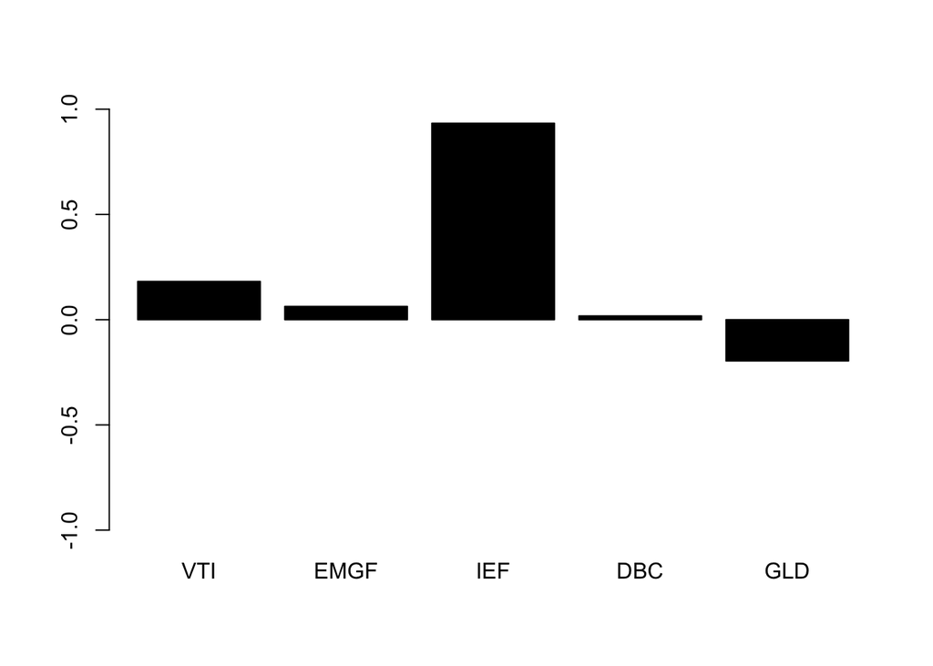

BL portfolio weights. Each bar represents a fund weight from left to right: VTI, EMGF, IEF, DBC, GLD.

# 3. Portfolio Insurance Strategies

Portfolio insurance strategies are designed to protect portfolios from downside risk. They work by hedging against losses in the stock market. There are two main types of portfolio insurance strategies:

- **Dynamic portfolio insurance:** Dynamic portfolio insurance strategies adjust the portfolio’s allocation to risky assets over time. This is done in response to changes in the market.
- **Static portfolio insurance:** Static portfolio insurance strategies maintain a fixed allocation to risky assets. This allocation is determined in advance and is not adjusted over time.

## 3.1 Packages

The same packages are referenced in 1.1

## 3.2 OBPI and CPPI strategies

We create the parameters for the simulation.

### 3.2.1 Parameters of the modelling

**Simulation Setup**

- The expected annual return (mu) is set to 5%.
- Annual volatility (sigma) is 20%.
- The initial price of the equity is $100.
- The risk-free rate is 2% per annum.
- The time horizon is 1 year, divided into 12 trading months.
- The number of trials for the Monte Carlo simulation is 10,000.

**Equity price simulation**

Equity prices are simulated using a geometric Brownian motion model, where the drift and diffusion components are based on the input parameters. The script generates a matrix of equity price paths.

**Strategies implementation**

- **OBPI strategy:** Uses Black-Scholes to price call options on the equity at each step.
- **CPPI strategy**: Adjusts the exposure to the risky asset based on a pre-defined floor and a multiplier that determines the level of investment in the risky asset relative to the cushion (the amount by which the asset value exceeds the floor).

### 3.2.2 Structure of the code

The code structure is as follows:

1. **Function Declaration:** The function **`simulate_scenario`** is declared with a number of parameters:
   - **`rf_scenario`**: A specific risk-free rate to use for the scenario.
   - **`n_sim`**: The number of simulations to run (default is 10,000, but it doesn’t seem to be used in the body of the function).
   - **`stress`**, **`sigma`**, **`mu`**, **`strike`**: Various constants used in the simulations, each with their default values.
2. **Constants Initialization:** Some internal constants such as **`delta`**, **`mat`**, and **`tol`** are defined. The **`delta`** represents a time step, **`mat`** represents the maturity (fixed to 1), and **`tol`** represents the tolerance (fixed to 0).
3. **Random Uniform Sequence:** A seed is set for reproducibility purposes, and then a random uniform sequence **`u`** of length **`n`** is generated.
4. **Moments Calculation:** Moments on the simulation path for risk-free rate, expected return, and volatility are computed.
5. **Stock Return and Equity Paths Simulation:** Stock returns **`r`** are simulated using the quantile function of the normal distribution (**`qnorm`**). Equity price paths for the stock (**`equity`**) and a risk-neutral pricing scenario (**`equityRNP`**) are then computed using the cumulated product function (**`cumprod`**).
6. **Call Option Simulation:** The call option price is simulated using the Black-Scholes formula, considering the current equity price, the strike price, risk-free rate, volatility, and time to maturity.
7. **Floor Value Calculation:** The minimum guaranteed value (**`floor`**) is calculated based on the risk-free rate and time.
8. **OBPI Simulation:** Option Based Portfolio Insurance (OBPI) is simulated using the **`floor`** and **`call`** values to determine the gearing and subsequently the OBPI call values.
9. **CPPI Simulation:** Constant Proportion Portfolio Insurance (CPPI) strategy is simulated in this section. It involves calculating multiple values like the cushion, multiplier, exposure ex-ante, and exposure ex-post. A loop is used to compute these values for each time step.

For the Monte Carlo simulation:

1. **Implementation of the Monte Carlo simulation on the data:** The model is performed and results are obtained for this quantitative technique.
2. **Return Statement:** The function finally returns a list containing the simulated equity, floor, OBPI call, and CPPI values.
3. **Visualization**: The script includes plotting functions to visualize the simulated price paths for equity, OBPI, and CPPI strategies, as well as histograms of the final values after the simulation period.
4. **Results summary**: The script calculates summary statistics for the final values of equity, OBPI, and CPPI strategies, which include measures like mean, median, and range.
5. **Return and volatility calculation**: Monthly returns are calculated for each strategy. The mean monthly return for each strategy is computed. Volatility is annualized by multiplying the monthly volatility by the square root of 12 (assuming monthly returns are uncorrelated).
6. **Results consolidation**: A data frame is created to hold the mean annualized return and annualized volatility for each strategy. The results are printed, which would provide insights into the performance and risk of each strategy.

## 3.3 Sensitivity analysis

We assess the following variables to understand how they can affect the payoff of the modelled OBPI and CPPI portfolios:

1. **Risk-Free Rate (`rf`)**: The risk-free rate affects the present value of the strike (used in calculating the floor). An increase in the risk-free rate decreases the present value, while a decrease increases it. The code demonstrates this sensitivity by simulating three scenarios: base, increased, and decreased risk-free rate.
2. **Stress Value (`stress`)**: Stress value in the code defines the risk level for CPPI strategy. It affects the multiplier that dictates how much of the cushion (difference between current portfolio value and floor) is invested in risky assets.
3. **Volatility (`sigma`)**: Volatility represents the uncertainty or risk regarding the magnitude of changes in an asset’s value. A higher volatility indicates that an asset’s value can potentially be spread out over a larger range of values. In the simulation, volatility affects the returns and also the Black-Scholes-like calculation for the call option.
4. **Return (`mu`)**: The expected return on the risky asset. This impacts the drift of the simulation path. A higher return would generally lead to higher asset values, all else being equal.
5. **Strike Price (`strike`)**: This represents an initial reference value from which different strategies are assessed. In the code, it acts as the initial value for Equity, OBPI, and CPPI. Changes in strike price will directly affect these initial values.

We analyse each variable and the sensitivity to different variations for each parameters.

We plot the results for the different sensitivities analysed.

**Risk-free rate (rf)**

- **Increase:** An increase in the risk-free rate will decrease the present value of the strike, which will increase the cost of the put option used in OBPI and CPPI. This will lead to lower payoffs for both strategies.
- **Decrease:** A decrease in the risk-free rate will increase the present value of the strike, which will decrease the cost of the put option used in OBPI and CPPI. This will lead to higher payoffs for both strategies.

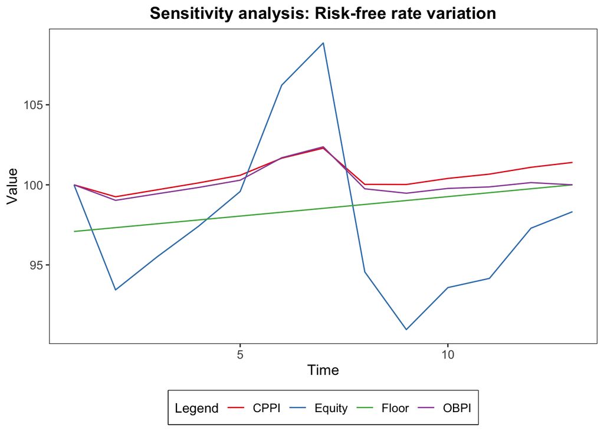

Sensitivity analysis using the risk-free rate.

**Stress value (stress)**

- **Increase:** An increase in the stress value will increase the multiplier used in CPPI, which will lead to a higher allocation to risky assets. This will increase the potential upside of the strategy, but it will also increase the downside risk.
- **Decrease:** A decrease in the stress value will decrease the multiplier used in CPPI, which will lead to a lower allocation to risky assets. This will decrease the potential upside of the strategy, but it will also decrease the downside risk.

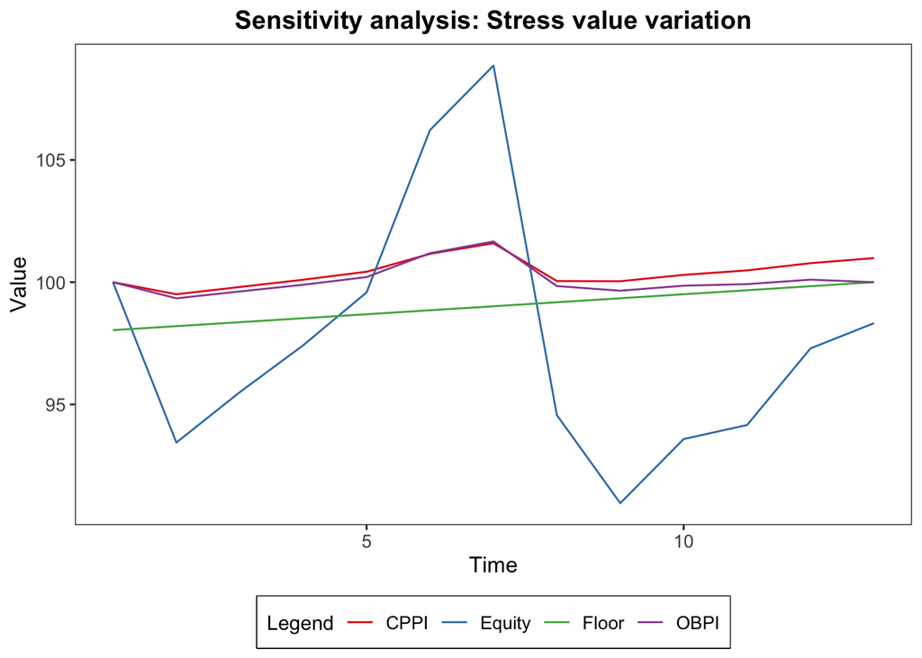

Sensitivity analysis using the stress value.

**Volatility (sigma)**

- **Increase:** An increase in volatility will increase the cost of the put option used in OBPI and CPPI. It will also increase the potential upside of CPPI, as the portfolio will be more exposed to risky assets. However, it will also increase the downside risk of CPPI.
- **Decrease:** A decrease in volatility will decrease the cost of the put option used in OBPI and CPPI. It will also decrease the potential upside of CPPI, as the portfolio will be less exposed to risky assets. However, it will also decrease the downside risk of CPPI.

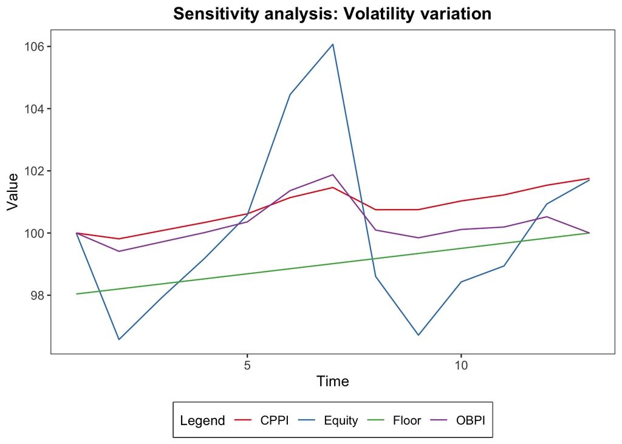

Sensitivity analysis using volatility.

**Return (mu)**

- **Increase:** An increase in the expected return will increase the value of the risky assets, which will lead to higher payoffs for both OBPI and CPPI.
- **Decrease:** A decrease in the expected return will decrease the value of the risky assets, which will lead to lower payoffs for both OBPI and CPPI.

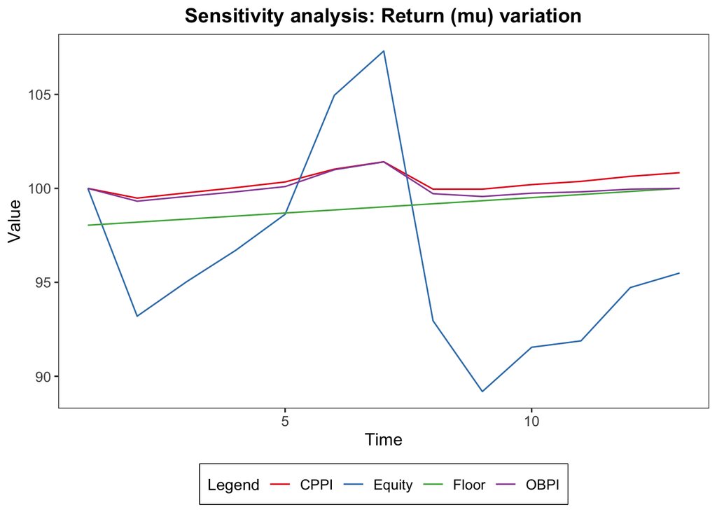

Sensitivity analysis using return (mu).

**Strike price (strike)**

- **Increase:** An increase in the strike price will increase the cost of the put option used in OBPI and CPPI. It will also decrease the initial value of the risky assets, which will lead to lower payoffs for both strategies.
- **Decrease:** A decrease in the strike price will decrease the cost of the put option used in OBPI and CPPI. It will also increase the initial value of the risky assets, which will lead to higher payoffs for both strategies.

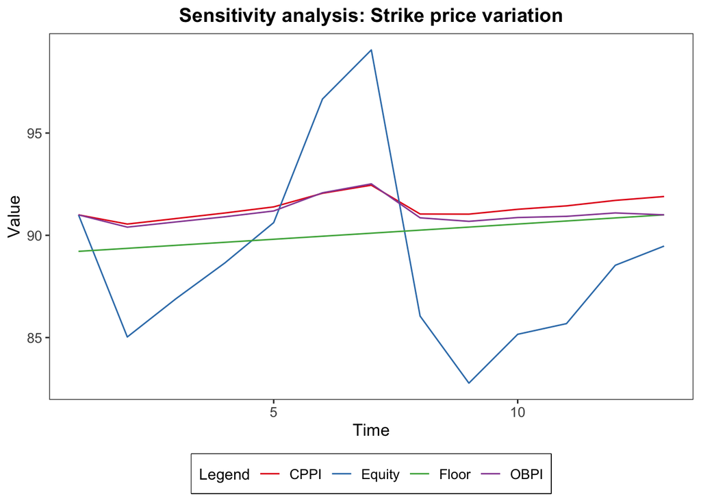

Sensitivity analysis using strike price.

The best strategy to use will depend on the individual investor’s risk tolerance and investment goals. Investors who are more risk-averse may prefer CPPI, while investors who are more risk-tolerant may prefer OBPI.

## 3.4 Monte Carlo simulation

### **3.4.1 Overview and utility**:

- Monte Carlo simulation is a computational technique that uses random sampling to obtain numerical results.
- It is particularly useful for assessing the impact of risk and uncertainty in prediction and forecasting models.
- To account for the variability in financial markets and model outcomes that are not deterministic.
- To create a range of possible outcomes and the probabilities that they will occur for uncertain variables.
- To help in making informed decisions under uncertainty by considering different scenarios and their potential impacts.

### **3.4.2 Components of Monte Carlo simulation in finance**

1. **Randomness**:
   - Incorporates elements of randomness reflecting the uncertainty and volatility in financial markets.
2. **Statistical Properties**:
   - Uses statistical properties (mean, variance) of historical data to simulate future price movements.
3. **Time Series Modeling**:
   - Models the evolution of financial instruments over time using time series analysis.

### **3.4.3 Application and results in this exercise**

1. **Equity Price Simulation**:
   - Simulated using a stochastic process (Geometric Brownian Motion) to reflect the random nature of stock prices.
   - Incorporates drift (expected return) and diffusion (volatility) derived from historical data.
2. **Investment Strategies**:
   - **OBPI**: Models an options-based strategy that provides downside protection.
   - **CPPI**: A dynamic allocation strategy that adjusts exposure based on a predetermined cushion.
3. **Simulation Execution**:
   - Runs the simulation over a large number of trials to capture a broad range of possible outcomes.
   - Each trial represents a potential future state of the market or asset price.
4. **Visualization**:
   - Price path plots for the simulated strategies over time.
   - Histograms showing the distribution of final values from the simulation.
5. **Summary Statistics**:
   - Provides key measures like mean, median, standard deviation, and percentiles to summarize the simulation results.
6. **Comparative Analysis**:
   - Compares the performance and risk of different strategies (Equity, OBPI, CPPI).
   - Helps in understanding the trade-offs between return and risk.

### 3.4.4 Histogram simulation plot

The three histograms below represent the distribution of final values from a Monte Carlo simulation for an equity simulation and two investment strategies, CPPI (Constant Proportion Portfolio Insurance) and OBPI (Option-Based Portfolio Insurance). Here is an analysis of each:

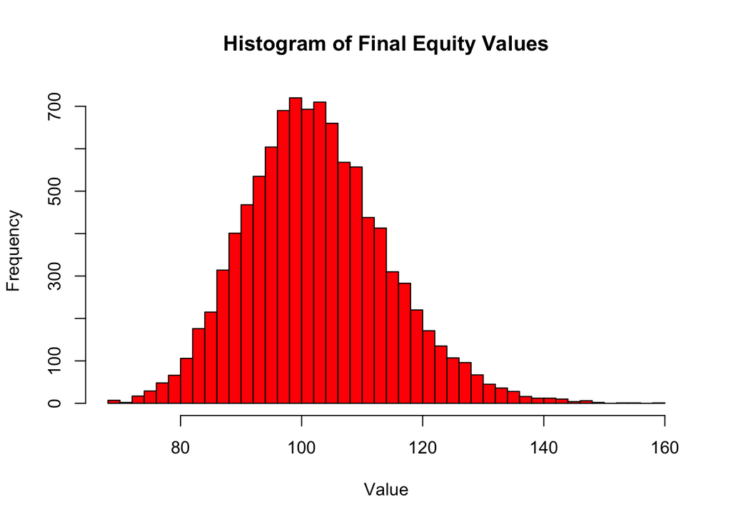

Histogram plot of final equity values.

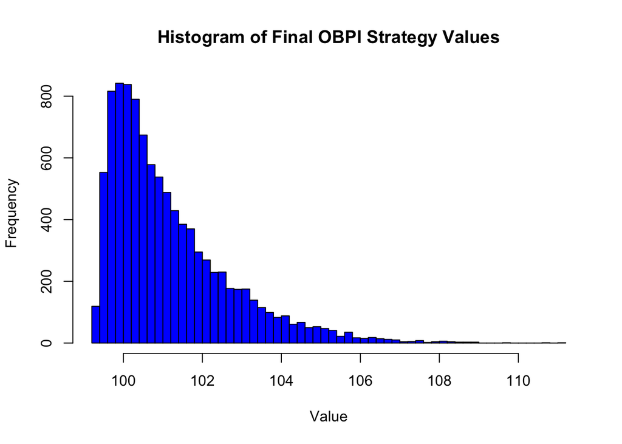

Histogram plot of final OBPI strategy values.

The CPPI histogram shows a right-skewed distribution, indicating that most of the final values are concentrated on the left side but there is a long tail towards higher values. The peak of the distribution is just above the 100 value mark, and the spread is narrower than the equity histogram, which may suggest less variability in the CPPI strategy outcomes compared to the equity simulation. The right skewness might also reflect a floor mechanism characteristic of CPPI strategies that limit downside risk but allow for participation in upside potential.

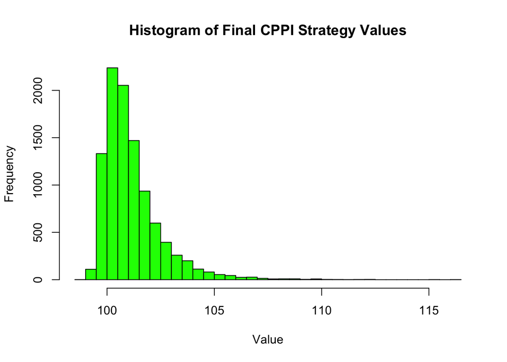

Histogram plot of final CPPI strategy values.